# EXPLORING PROSPER LOAN DATASET

## 6.0 Data Analysis

> - In this section, We will explore our data systematically by building univariate and bivariate visualizations.
> - To have an idea of how the numeric values are distributed, we will first compute the descriptive statistics of the relevant numeric columns. Doing this will be helpful in creating our histogram bins for univariate explorations.

```python
# Determining the discriptive statistics
clean_df.describe()
```

|  | Term | EmploymentStatusDuration | DebtToIncomeRatio | StatedMonthlyIncome | LoanOriginalAmount | ProsperScore | BorrowerAPR |
| --- | --- | --- | --- | --- | --- | --- | --- |
| count | 31037.000000 | 31037.000000 | 31037.000000 | 31037.000000 | 31037.000000 | 31037.000000 | 31037.000000 |
| mean | 42.818700 | 105.641621 | 0.258661 | 5940.875251 | 9306.250797 | 6.047782 | 0.224232 |
| std | 11.705389 | 97.322442 | 0.300263 | 4548.009095 | 6377.819266 | 2.355436 | 0.079140 |
| min | 12.000000 | 0.000000 | 0.000000 | 2.416667 | 1000.000000 | 1.000000 | 0.045830 |
| 25% | 36.000000 | 32.000000 | 0.150000 | 3513.500000 | 4000.000000 | 4.000000 | 0.163040 |
| 50% | 36.000000 | 77.000000 | 0.220000 | 5000.000000 | 8000.000000 | 6.000000 | 0.215660 |
| 75% | 60.000000 | 151.000000 | 0.320000 | 7166.666667 | 14800.000000 | 8.000000 | 0.287800 |
| max | 60.000000 | 755.000000 | 10.010000 | 394400.000000 | 35000.000000 | 11.000000 | 0.423950 |

### 6.1 Univariate Exploration

> We shall use the "Question-Visualization-Observations" framework throughout our exploration. This framework will involve **asking a question from the data, creating a visualization to find answers, and then recording observations after each visualisation.**

### Question A: How are Borrower APR values distributed in the dataset?

### `Visualization`

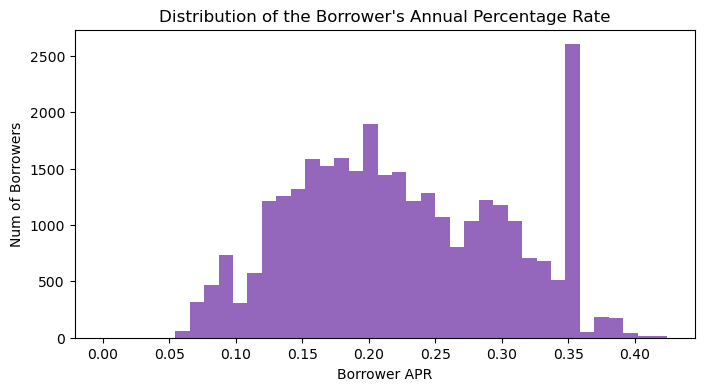

```python
# Pre our seaborn color for our visuals
colors = sns.color_palette('tab10')


# Create 40 evenly spaced bins for Borrower APR from zero to the maximum value
bins = np.linspace(0, clean_df.BorrowerAPR.max(), 40)

plt.figure(figsize=(8, 4))
plt.hist(data=clean_df, x='BorrowerAPR', bins=bins, color = colors[4]);
plt.xticks(np.arange(0, 0.45, 0.05))
plt.xlabel('Borrower APR');
plt.ylabel('Num of Borrowers')
plt.title("Distribution of the Borrower's Annual Percentage Rate");
```

### Question B. What is the distribution of loan amounts requested by borrowers?

### `Visualization`

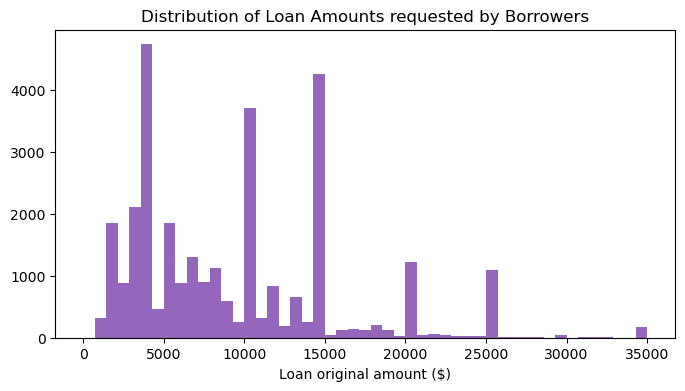

```python
plt.figure(figsize=(8, 4))
bins = np.linspace(0, clean_df.LoanOriginalAmount.max(), 50)
plt.hist(data=clean_df, x='LoanOriginalAmount', bins=bins, color = colors[4])
plt.xlabel('Loan original amount ($)');
plt.title("Distribution of Loan Amounts requested by Borrowers");
```

### `Observation`

> One can observe that very few customers asked for loans that are more than 15000USD. A good number request for loans of 5000USD, or in round figure of 5000USD for easy of loan repayment.

### Question C. Determine the distribution of Prosper rating, Income range and Employment Status

### `Visualization`

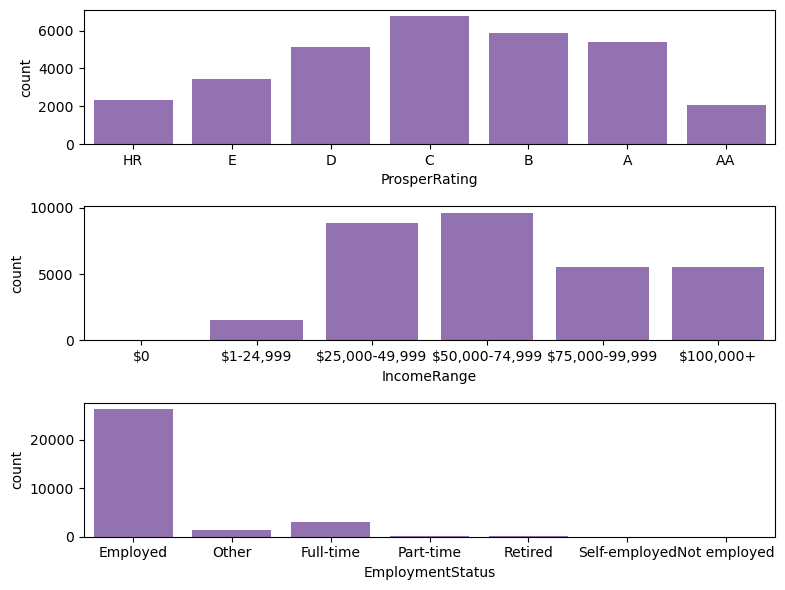

```python
columns = ['ProsperRating', 'IncomeRange', 'EmploymentStatus']

fig, ax = plt.subplots(nrows=3, figsize=(8, 6))

for col, index in zip(columns, range(3)):
    sns.countplot(data=clean_df, x=clean_df[col],color = colors[4], ax= ax[index])
plt.tight_layout();
```

### Question D. What is the distribution of Borrower's Employment Status Duration?

### `Visualization`

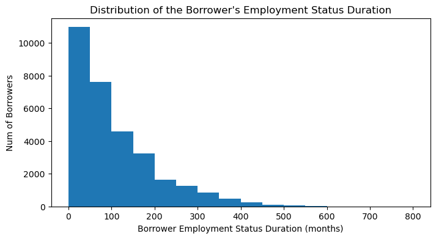

```python
# Plot the distribution of the EmploymentstatusDuration
rate_bins = np.arange(clean_df.EmploymentStatusDuration.min(), clean_df.EmploymentStatusDuration.max()+50, 50)

plt.figure(figsize = [8, 4])

plt.hist(data=clean_df, x='EmploymentStatusDuration', bins=rate_bins)
plt.xlabel('Borrower Employment Status Duration (months)');
plt.ylabel('Num of Borrowers')
plt.title("Distribution of the Borrower's Employment Status Duration");
```

### `Observations`

> - The distribution of Employment Status Duration is right skewed.
> - A good maority of the borrowers have an Employment duration around 4 years.

### Question E. What is the values of Debt-to-income ratio of the borrowers?

### `Visualization`

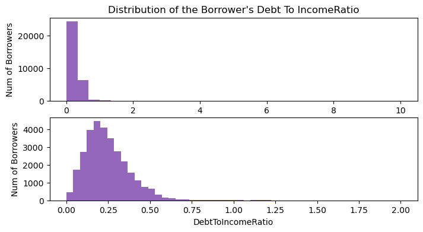

```python
plt.figure(figsize=(8, 4))

# PLotting a distribution with 30 bins.
plt.subplot(2,1,1)
plt.hist(data=clean_df, x='DebtToIncomeRatio', bins=30, color = colors[4])
plt.xlabel('DebtToIncomeRatio');
plt.ylabel('Num of Borrowers')
plt.title("Distribution of the Borrower's Debt To IncomeRatio")

# PLoting with a closer and spaced bins
bins = np.linspace(0, 2, 50)
plt.subplot(2,1,2)
plt.hist(data=clean_df, x='DebtToIncomeRatio', bins=bins, color = colors[4])
plt.xlabel('DebtToIncomeRatio');
plt.ylabel('Num of Borrowers');
```

### `Observations`

> - The Debt-to-Income ratio is right skewed
> - Most of the values are distributed btween 0 and 1. We can infer that most borrowrers apply for loans they can be able to repay.
> - The zoomed in analysis show that the distribution is mostly within 0.20 and 0.30. It is as if most of the borrowers maintain a debt ratio of one-fifth of their salary.